# Module 3 — From Biomarkers to Gene Regulatory Networks

BBCC2026 Tutorial: How Does Gene Regulation Differ Between Histology Subgroups?

Francesco Cecere** · *Senior Bioinformatic Researcher* · AORN Santobono-Pausilipon IRCCS

Eva Luna Tarallo** · *Junior Bioinformatic Researcher* · AORN Santobono-Pausilipon IRCCS

20 October 2026

# From Module 2

Module 2 used limma to produce two lists of DEGs, using 6 normal samples as controls: Favorable vs. Control and Unfavorable vs. Control. This module takes the DEGs of both lists together and asks how they **regulate each other** in three conditions: Favorable tumors, Unfavorable tumors and normal kidney. Comparing the three networks, we look for the hub regulators of each condition and, finally, for a candidate therapeutic biomarker specific to Unfavorable Wilms tumor.

**Session plan:** why a ranked list isn’t the end of the story → gene regulatory networks → building the three networks → overlapping the networks: shared edges and hubs → Unfavorable-specific biomarker → closing pediatric lens.

# Part 1 — Why a Ranked Gene List Isn’t the End of the Story

Module 2 answered one question, gene by gene: *is this gene expressed differently in the tumor than in normal kidney?* That question treats every gene in isolation — it says nothing about whether two candidate genes **influence each other**, or sit in entirely separate pathways.

**Reframing the arc:** Module 2 found candidates by asking “is this gene behaving abnormally compared to normal kidney?” Module 3 asks a different question about those same candidates: **“how do they work together, and does that change between the two histology groups?”** A single gene’s p-value cannot answer that as It requires looking at the candidate genes **as a system**, which is exactly what a gene regulatory network does.

**What we’re building toward.** We will infer **three** separate networks over the same panel of Module 2’s DEGs: one using the 82 favorable-histology tumors, one using the 42 unfavorable-histology tumors, and one using the 6 normal samples as a **baseline network**. We then overlap them to find which regulators are hubs in which condition, and look for a hub that is **specific to Unfavorable tumors**: a candidate biomarker.

# Part 2 — Gene Regulatory Networks in Plain Language

A **gene regulatory network (GRN)** is just a diagram: each **node** is a gene, and an **edge** between two genes means “knowing one gene’s expression level helps predict the other’s across these samples”.

# Part 3 — Building the Three Networks

We now infer three real networks, **Favorable**, **Unfavorable** and **Control**, over the **same set of genes**, so that they can be compared edge by edge and hub by hub.

## Step 1 — The Gene Panel: Strong DEGs from Both Comparisons

The panel comes straight from Module 2: the **union** of the DEGs of *Favorable vs Control* and *Unfavorable vs Control*, i.e. every gene that is a DEG in at least one of the two comparisons, whatever its category (shared, Favorable-only or Unfavorable-only).

GENIE3 grows one random forest per gene, so a network over all of them would take hours, far too long to run live. We therefore keep only the **strong DEGs: |log2FC| > 3** (at least an 8-fold change versus normal kidney) in at least one comparison.

```r
de_favorable_vs_control   <- read_csv("results/differential_expression_favorable_vs_control.csv", show_col_types = FALSE)
de_unfavorable_vs_control <- read_csv("results/differential_expression_unfavorable_vs_control.csv", show_col_types = FALSE)

tumor_tpm_raw <- read_csv("data/TARGET_WT_gene_expression_tpm.csv", show_col_types = FALSE) %>%
  rename(gene_symbol = gene_name)
control_tpm_raw <- read_csv("data/TARGET_WT_control_gene_expression_tpm.csv", show_col_types = FALSE) %>%
  rename(gene_symbol = gene_name)
sample_metadata <- read_csv("data/sample_metadata.csv", show_col_types = FALSE)

# Curated list of 1,639 human transcription factors (Lambert et al., Cell 2018).
human_tfs <- readLines("data/human_transcription_factors_Lambert2018.txt")
```

```r
panel_log2fc_cutoff <- 3

strong_degs <- function(de_table) {
  de_table %>% filter(status != "Not DEG", abs(log2FC) > panel_log2fc_cutoff) %>% pull(gene_symbol)
}

strong_favorable   <- strong_degs(de_favorable_vs_control)
strong_unfavorable <- strong_degs(de_unfavorable_vs_control)
panel_genes        <- union(strong_favorable, strong_unfavorable)

# Only transcription factors are allowed to act as regulators (see below).
panel_tfs <- intersect(panel_genes, human_tfs)
```

| gene_set | genes |
| --- | --- |
| Strong DEGs, Favorable vs Control | 732 |
| Strong DEGs, Unfavorable vs Control | 727 |
| Strong DEGs in both | 658 |
| Panel (union) | 801 |
| Transcription factors in the panel | 85 |

**Why only transcription factors as regulators?** GENIE3 can in principle let every gene predict every other gene, but that is both slow and biologically loose: the genes that actually *regulate* the expression of other genes are mainly **transcription factors (TFs)**, proteins that bind DNA and switch genes on or off. So we give GENIE3 the `regulators = panel_tfs` argument: every panel gene is a possible **target**, but only the 85 TFs of the panel can be **regulators**. This is standard practice in network inference, and it makes the run about ten times faster. A consequence to keep in mind: **only TFs can become hubs**.

## Step 2 — One Expression Matrix per Condition

```r
# Genes x samples matrix of log2(TPM + 1) for the panel, from a TPM table.
panel_matrix <- function(tpm_table, sample_ids) {
  m <- as.matrix(tpm_table[, sample_ids])
  rownames(m) <- tpm_table$gene_symbol
  log2(m[panel_genes, ] + 1)
}

favorable_ids   <- sample_metadata %>% filter(histologic_subtype == "Favorable")   %>% pull(case_submitter_id)
unfavorable_ids <- sample_metadata %>% filter(histologic_subtype == "Unfavorable") %>% pull(case_submitter_id)

matrix_favorable   <- panel_matrix(tumor_tpm_raw, favorable_ids)
matrix_unfavorable <- panel_matrix(tumor_tpm_raw, unfavorable_ids)
matrix_control     <- panel_matrix(control_tpm_raw, colnames(control_tpm_raw)[-1])
```

| condition | genes | samples |
| --- | --- | --- |
| Favorable | 801 | 82 |
| Unfavorable | 801 | 42 |
| Control | 801 | 6 |

## Step 3 — Running GENIE3 in Each Condition

```r
#nTrees = 500 (default 1000) keeps the run short.
run_genie3 <- function(expr_matrix) {
  set.seed(20261013)
  GENIE3(expr_matrix, regulators = panel_tfs, nTrees = 500, nCores = 1, verbose = FALSE)
}

weights_favorable   <- run_genie3(matrix_favorable)
weights_unfavorable <- run_genie3(matrix_unfavorable)
weights_control     <- run_genie3(matrix_control)
```

GENIE3 returns a weight for every TF → target pair: how useful that TF was for predicting that target. Almost all weights are tiny; we keep the **300 strongest edges** of each network.

```r
n_top_edges <- 300

top_edges <- function(weights) {
  getLinkList(weights) %>%
    as_tibble() %>%
    mutate(regulatoryGene = as.character(regulatoryGene), targetGene = as.character(targetGene)) %>%
    arrange(desc(weight)) %>%
    slice_head(n = n_top_edges)
}

edges_favorable   <- top_edges(weights_favorable)
edges_unfavorable <- top_edges(weights_unfavorable)
edges_control     <- top_edges(weights_control)

dir.create("results", showWarnings = FALSE)
write_csv(edges_favorable,   "results/gene_network_favorable_edges.csv")
write_csv(edges_unfavorable, "results/gene_network_unfavorable_edges.csv")
write_csv(edges_control,     "results/gene_network_control_edges.csv")
```

| network | regulatoryGene | targetGene | weight |
| --- | --- | --- | --- |
| Favorable | IRX2 | C5orf38 | 0.29 |
| Favorable | IRX5 | IRX3 | 0.233 |
| Favorable | IRX3 | IRX5 | 0.216 |
| Favorable | HNF1B | CDH16 | 0.201 |
| Favorable | HNF1B | GJB1 | 0.196 |
| Favorable | HNF1B | SERPINF2 | 0.193 |
| Favorable | HNF1B | CCDC198 | 0.19 |
| Favorable | FOS | FOSB | 0.186 |
| Favorable | CENPA | PTTG1 | 0.172 |
| Favorable | CENPA | CDK1 | 0.17 |

[output cut: 890 more lines]

## Step 4 — Visualizing the Three Networks

In the plots below each **node** is a gene and each **arrow** goes from a TF to one of its predicted targets. **Diamonds are TFs**, dots are targets. Node colors show the gene’s category from Module 2’s UpSet plot:

- **red**: up in both tumor subtypes vs normal kidney; **blue**: down in both;
- **purple**: DEG only in Unfavorable; **orange**: DEG only in Favorable.

Node size grows with the number of targets (the bigger, the more hub-like). Hover a node to highlight its direct connections, or pick a gene from the dropdown.

```r
gene_category <- full_join(
  de_favorable_vs_control   %>% select(id = gene_symbol, fav = status),
  de_unfavorable_vs_control %>% select(id = gene_symbol, unf = status),
  by = "id"
) %>%
  filter(id %in% panel_genes) %>%
  mutate(category = case_when(
    fav == "Up"   & unf == "Up"   ~ "Shared up",
    fav == "Down" & unf == "Down" ~ "Shared down",
    fav == "Not DEG"              ~ "Unfavorable only",
    unf == "Not DEG"              ~ "Favorable only",
    TRUE                          ~ "Opposite direction"
  ))

category_colors <- c(`Shared up` = "#e74c3c", `Shared down` = "#2980b9",
                     `Unfavorable only` = "#8e44ad", `Favorable only` = "#e67e22",
                     `Opposite direction` = "#7f8c8d")

plot_network <- function(edges, title) {
  out_degree <- count(edges, regulatoryGene, name = "n_targets")
  nodes <- tibble(id = unique(c(edges$regulatoryGene, edges$targetGene))) %>%
    left_join(gene_category, by = "id") %>%
    left_join(out_degree, by = c(id = "regulatoryGene")) %>%
    mutate(
      n_targets = replace_na(n_targets, 0),
      label = id,
      shape = if_else(id %in% panel_tfs, "diamond", "dot"),
      color = category_colors[category],
      size  = 10 + 2 * n_targets,
      title = paste0(id, "<br>", category, "<br>targets: ", n_targets)
    )

  visNetwork(nodes, edges %>% transmute(from = regulatoryGene, to = targetGene),
             main = title, height = "600px", width = "100%") %>%
    visEdges(arrows = "to", color = list(color = "#bdc3c7", opacity = 0.6)) %>%
    visOptions(highlightNearest = TRUE, nodesIdSelection = TRUE) %>%
    # Layout computed once in R (seeded), physics off: fast and identical on every knit.
    visIgraphLayout(layout = "layout_with_fr", randomSeed = 1, physics = FALSE)
}
```

[interactive chart not shown]

### The Control Network: Read With Real Caution

[interactive chart not shown]

# Part 4 — Overlapping the Networks

With three networks over the same genes, we can compare them directly at two levels: **edges** (are the same TF → target links found?) and **hubs** (are the same TFs the most connected?).

## Shared Edges

```r
edge_ids <- function(edges) paste(edges$regulatoryGene, "→", edges$targetGene)

edge_sets <- list(Favorable = edge_ids(edges_favorable),
                  Unfavorable = edge_ids(edges_unfavorable),
                  Control = edge_ids(edges_control))

edge_overlap <- combn(names(edge_sets), 2, simplify = FALSE) %>%
  map_dfr(function(pair) {
    a <- edge_sets[[pair[1]]]; b <- edge_sets[[pair[2]]]
    tibble(networks = paste(pair, collapse = " vs "),
           shared_edges = length(intersect(a, b)),
           jaccard = round(length(intersect(a, b)) / length(union(a, b)), 3))
  })
```

| networks | shared_edges | jaccard |
| --- | --- | --- |
| Favorable vs Unfavorable | 64 | 0.119 |
| Favorable vs Control | 4 | 0.007 |
| Unfavorable vs Control | 2 | 0.003 |

**Reading this table.** The two tumor networks share more edges with each other than either does with the control network: their strongest regulatory links are not the ones present in normal kidney. Part of the disagreement with the control network is real rewiring, but part is simply noise from its 6 samples; this table cannot tell the two apart.

## Hub Genes in Each Network

A TF’s **out-degree** is the number of targets it has among the network’s top 300 edges: the more targets, the more hub-like the TF. The table lists every TF of the panel with its out-degree in all three networks.

```r
hub_table <- bind_rows(Favorable = edges_favorable, Unfavorable = edges_unfavorable,
                       Control = edges_control, .id = "network") %>%
  count(network, regulatoryGene, name = "out_degree") %>%
  pivot_wider(names_from = network, values_from = out_degree, values_fill = 0) %>%
  right_join(tibble(regulatoryGene = panel_tfs), by = "regulatoryGene") %>%
  mutate(across(c(Favorable, Unfavorable, Control), ~ replace_na(.x, 0))) %>%
  select(TF = regulatoryGene, Control, Favorable, Unfavorable) %>%
  arrange(desc(Unfavorable))

write_csv(hub_table, "results/gene_network_hub_comparison.csv")
```

| TF | Control | Favorable | Unfavorable |
| --- | --- | --- | --- |
| HNF1B | 4 | 48 | 32 |
| ELF3 | 2 | 8 | 26 |
| NR1H4 | 4 | 16 | 17 |
| E2F1 | 5 | 2 | 16 |
| IRX1 | 18 | 4 | 15 |
| E2F2 | 1 | 5 | 13 |
| FOXM1 | 1 | 31 | 12 |
| CEBPD | 3 | 0 | 11 |
| TFAP2B | 5 | 5 | 10 |
| IRF6 | 2 | 0 | 8 |

[output cut: 75 more lines]

To compare the networks at a glance, we take the **top 10 hubs** of each network (ties at the 10th place are all kept) and plot their out-degree in all three conditions.

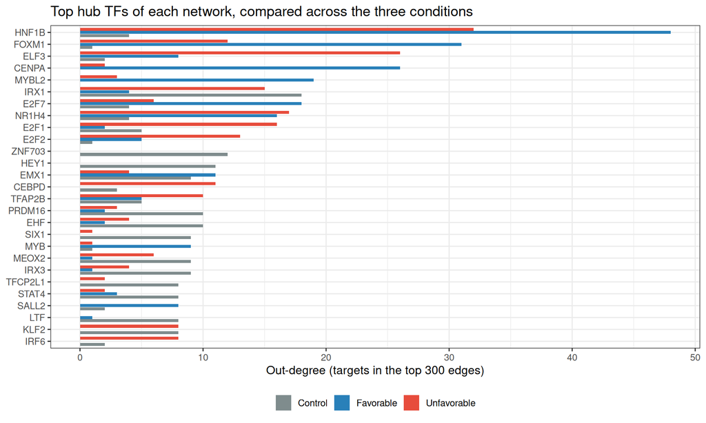

**What to look for.** A TF with a long bar in **all three** colors is a hub everywhere: probably a general feature of this gene panel. A TF with a long **red** bar and short blue and gray bars is a hub **only in Unfavorable tumors**: a candidate for regulatory rewiring specific to anaplastic histology. That is exactly what Part 5 looks for.

# Part 5 — Toward an Unfavorable-Specific Therapeutic Biomarker

The clinical question: **is there a regulator that becomes a hub specifically in anaplastic (Unfavorable) Wilms tumor, having more targets there than in either Favorable or Control?** We focus on **gains only**: a TF whose regulatory role is newly active in Unfavorable is a more directly actionable candidate than one that merely loses a role it has elsewhere.

```r
candidates <- hub_table %>%
  mutate(hub_specificity = Unfavorable - pmax(Favorable, Control)) %>%
  filter(hub_specificity > 0) %>%
  arrange(desc(hub_specificity))

top5_candidates <- candidates %>% slice_head(n = 5)
```

| TF | Control | Favorable | Unfavorable | hub_specificity |
| --- | --- | --- | --- | --- |
| ELF3 | 2 | 8 | 26 | 18 |
| E2F1 | 5 | 2 | 16 | 11 |
| E2F2 | 1 | 5 | 13 | 8 |
| CEBPD | 3 | 0 | 11 | 8 |
| IRF6 | 2 | 0 | 8 | 6 |
| TFAP2B | 5 | 5 | 10 | 5 |
| LBX2 | 1 | 2 | 5 | 3 |
| MEIS1 | 2 | 0 | 5 | 3 |
| ETV4 | 1 | 0 | 4 | 3 |
| ARID3B | 5 | 2 | 7 | 2 |

[output cut: 5 more lines]

## Shortlist: Top 5 Candidates, Side by Side

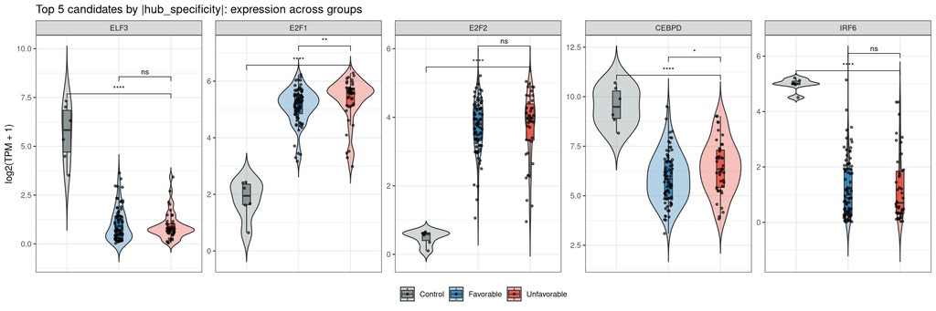

**Reading this panel.** Each facet is one TF’s `log2(TPM + 1)` in Control / Favorable / Unfavorable (gray / blue / red, left to right in every panel). Significance brackets compare Unfavorable against Control and against Favorable. A convincing candidate should show both a real network signal **and** a plausible expression pattern.

## A Closer Look: E2F1

**E2F1** is the chosen candidate: 16 targets in Unfavorable versus 2 in Favorable and 5 in Control. The question that matters most for interpretation: **are the connections E2F1 gained specifically in Unfavorable tumors — the ones it does *not* have in Favorable or Control — genes with a real, independent cancer link?**

```r
candidate_gene <- "E2F1"

e2f1_targets <- bind_rows(Favorable = edges_favorable, Unfavorable = edges_unfavorable, Control = edges_control, .id = "network") %>%
  filter(regulatoryGene == candidate_gene) %>%
  select(network, targetGene, weight)

targets_elsewhere <- e2f1_targets %>% filter(network != "Unfavorable") %>% pull(targetGene) %>% unique()

e2f1_targets_annotated <- e2f1_targets %>%
  filter(network == "Unfavorable") %>%
  mutate(new_in_unfavorable = !targetGene %in% targets_elsewhere) %>%
  arrange(desc(weight))

n_new_targets <- sum(e2f1_targets_annotated$new_in_unfavorable)
```

| network | targetGene | weight | new_in_unfavorable |
| --- | --- | --- | --- |
| Unfavorable | E2F2 | 0.126 | False |
| Unfavorable | CRACD | 0.107 | True |
| Unfavorable | GTSE1 | 0.101 | True |
| Unfavorable | MCM2 | 0.0922 | True |
| Unfavorable | SKA3 | 0.092 | True |
| Unfavorable | SMC4 | 0.0883 | True |
| Unfavorable | NCAPG | 0.0873 | True |
| Unfavorable | MKI67 | 0.0873 | True |
| Unfavorable | KIF4A | 0.0856 | True |
| Unfavorable | BUB1B | 0.0854 | True |

[output cut: 6 more lines]

15 of E2F1’s 16 Unfavorable targets are new in exactly this sense.

[interactive chart not shown]

### Are the New Connections Cancer-Related?

**E2F1 itself is a well-established cancer gene** — the RB-pathway’s main activator of G1/S cell-cycle entry, with higher expression predicting shorter survival in several adult cancers (e.g. breast). First, the expression of its 15 Unfavorable-specific targets, across all three groups:

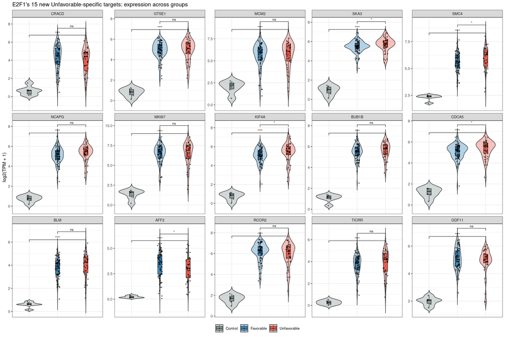

Of those 15, the ones actually worth a second look are the ones where **Favorable vs. Unfavorable itself** is significant in the panel above, not just “present as a network edge in Unfavorable,” but a real expression difference between the two tumor subtypes directly:

```r
fav_vs_unf_significance <- new_targets_expr %>%
  filter(group %in% c("Favorable", "Unfavorable")) %>%
  group_by(gene_symbol) %>%
  summarise(
    p_value             = wilcox.test(log2_tpm ~ group)$p.value,
    median_favorable    = round(median(log2_tpm[group == "Favorable"]), 2),
    median_unfavorable  = round(median(log2_tpm[group == "Unfavorable"]), 2),
    .groups = "drop"
  ) %>%
  mutate(
    higher_in = if_else(median_unfavorable > median_favorable, "Unfavorable", "Favorable"),
    p_value   = signif(p_value, 3)
  ) %>%
  filter(p_value < 0.05) %>%
  arrange(p_value)
```

| gene_symbol | p_value | median_favorable | median_unfavorable | higher_in |
| --- | --- | --- | --- | --- |
| KIF4A | 0.0184 | 5.1 | 5.49 | Unfavorable |
| CDCA5 | 0.0206 | 5.22 | 5.59 | Unfavorable |
| SMC4 | 0.0243 | 5.6 | 6.28 | Unfavorable |
| AFF2 | 0.0294 | 3.64 | 3.02 | Favorable |
| SKA3 | 0.0306 | 5.5 | 5.77 | Unfavorable |

## Is E2F1 a Druggable Biomarker?

We query **DGIdb** (the Drug Gene Interaction Database, dgidb.org) for E2F1 and all 15 new Unfavorable-specific targets at once, and ask it directly: does *any* drug, approved or experimental, have a recorded interaction with each of these genes?

```r
dgidb_genes <- c(candidate_gene, new_targets)

dgidb_query <- sprintf(
  '{ genes(names: [%s]) { nodes { name interactions { drug { name approved } } } } }',
  paste0('"', dgidb_genes, '"', collapse = ",")
)

dgidb_response <- POST("https://dgidb.org/api/graphql", body = list(query = dgidb_query), encode = "json")

dgidb_nodes <- content(dgidb_response, as = "parsed", simplifyVector = TRUE)$data$genes$nodes

dgidb_per_gene <- map_dfr(seq_len(nrow(dgidb_nodes)), function(i) {
  ints <- dgidb_nodes$interactions[[i]]
  # Unique drug names, approved drugs first -- kept as a list-column so
  # the full name list survives the later join/arrange, not just a count.
  drug_names <- if (is.null(ints) || nrow(ints) == 0) {
    character(0)
  } else {
    tibble(name = ints$drug$name, approved = ints$drug$approved) %>%
      distinct(name, .keep_all = TRUE) %>%
      arrange(desc(approved)) %>%
      pull(name)
  }
  tibble(
    gene_symbol    = dgidb_nodes$name[i],
    n_interactions = if (is.null(ints)) 0L else nrow(ints),
    n_approved     = if (is.null(ints)) 0L else sum(ints$drug$approved, na.rm = TRUE),
    drug_names     = list(drug_names)
  )
})

dgidb_counts <- tibble(gene_symbol = dgidb_genes) %>%
  left_join(dgidb_per_gene, by = "gene_symbol") %>%
  mutate(
    n_interactions = replace_na(n_interactions, 0L),
    n_approved     = replace_na(n_approved, 0L),
    drug_names     = map(drug_names, ~ if (is.null(.x)) character(0) else .x)
  ) %>%
  arrange(desc(n_interactions))
```

[interactive chart not shown]

| gene_symbol | n_interactions | n_approved | drug_names |
| --- | --- | --- | --- |
| BLM | 102 | 20 | ['TRIMETREXATE', 'BEXAROTENE', 'DAUNORUBICIN HYDROCHLORIDE', 'QUERCETIN', 'DOXORUBICIN HYDROCHLORIDE', 'MITOXANTRONE HYDROCHLORIDE', 'MITOXANTRONE', 'METHYLENE BLUE ANHYDROUS', 'LIOTHYRONINE SODIUM', … |
| E2F1 | 31 | 19 | ['ACETYLCYSTEINE', 'FLUOROURACIL', 'PRIMAQUINE', 'ASCORBIC ACID', 'BORTEZOMIB', 'DOXORUBICIN HYDROCHLORIDE', 'IRINOTECAN HYDROCHLORIDE', 'METHOTREXATE', 'PACLITAXEL PROTEIN-BOUND', 'ESTRADIOL VALERATE… |
| RCOR2 | 8 | 2 | ['AXITINIB', 'TALAZOPARIB', 'BARASERTIB', 'BI-2536', 'TOZASERTIB', 'TAK-901', 'DANUSERTIB', 'BARASERTIB-HQPA'] |
| MKI67 | 2 | 2 | ['SUNITINIB', 'ABEMACICLIB'] |
| GTSE1 | 1 | 1 | ['FLUBENDAZOLE'] |
| SKA3 | 1 | 0 | ['CENP-E INHIBITOR GSK-923295A'] |
| BUB1B | 1 | 0 | ['GEMCITABINE PRODRUG LY2334737'] |
| CRACD | 0 | 0 | [] |
| MCM2 | 0 | 0 | [] |
| SMC4 | 0 | 0 | [] |

[output cut: 6 more lines]

The top 3 genes by recorded interaction count, with the actual drug names behind that count (approved drugs listed first; capped at 10 names per gene since some genes have dozens):

```r
top3_drugs <- dgidb_counts %>%
  slice_head(n = 3) %>%
  mutate(
    drug_names_shown = map_chr(drug_names, function(names) {
      if (length(names) == 0) return("(none)")
      shown <- if (length(names) > 10) names[1:10] else names
      label <- paste(shown, collapse = ", ")
      if (length(names) > 10) paste0(label, ", ... (", length(names) - 10, " more)") else label
    })
  ) %>%
  select(gene_symbol, n_interactions, n_approved, drug_names_shown)
```

| gene_symbol | n_interactions | n_approved | drug_names_shown |
| --- | --- | --- | --- |
| BLM | 102 | 20 | TRIMETREXATE, BEXAROTENE, DAUNORUBICIN HYDROCHLORIDE, QUERCETIN, DOXORUBICIN HYDROCHLORIDE, MITOXANTRONE HYDROCHLORIDE, MITOXANTRONE, METHYLENE BLUE ANHYDROUS, LIOTHYRONINE SODIUM, NOREPINEPHRINE, ...… |
| E2F1 | 31 | 19 | ACETYLCYSTEINE, FLUOROURACIL, PRIMAQUINE, ASCORBIC ACID, BORTEZOMIB, DOXORUBICIN HYDROCHLORIDE, IRINOTECAN HYDROCHLORIDE, METHOTREXATE, PACLITAXEL PROTEIN-BOUND, ESTRADIOL VALERATE, ... (20 more) |
| RCOR2 | 8 | 2 | AXITINIB, TALAZOPARIB, BARASERTIB, BI-2536, TOZASERTIB, TAK-901, DANUSERTIB, BARASERTIB-HQPA |

# Part 6 — Closing Pediatric Lens

Pediatric rare disease means two things at once: **very few samples**, and a **uniquely sensitive population** to try to collect more from. That combination is exactly why a result like E2F1’s matters here — with only 42 Unfavorable tumors and 6 real controls to work with, and essentially no realistic way to get many more, finding and correctly flagging a candidate target in the data that already exists is as important as it gets.

Generated on 20 October 2026 · Francesco Cecere (Senior Bioinformatic Researcher) · Eva Luna Tarallo (Junior Bioinformatic Researcher) · AORN Santobono-Pausilipon IRCCS